# Optimal Treatment Analysis

## Outcome Variable

**Outcome Variable:** ever_wasted

## Predictor Variables

**Intervention Variable:** perdiar24

**Adjustment Set:**

- arm
- sex
- W_mage
- meducyrs
- W_birthwt
- W_birthlen
- W_nrooms
- month
- brthmon
- impfloor
- impsan
- safeh20
- delta_W_mage
- delta_meducyrs
- delta_W_birthwt
- delta_W_birthlen
- delta_W_nrooms
- delta_month
- delta_brthmon
- delta_impfloor
- delta_impsan
- delta_safeh20

## Stratifying Variables

The analysis was stratified on these variable(s):

- agecat
- studyid
- country

## Data Summary

| agecat | studyid | country | perdiar24 | ever_wasted | n_cell | n |
| --- | --- | --- | --- | --- | --- | --- |
| 0-24 months (no birth wast) | ki0047075b-MAL-ED | BANGLADESH | (0%, 5%] | 0 | 112 | 261 |
| 0-24 months (no birth wast) | ki0047075b-MAL-ED | BANGLADESH | (0%, 5%] | 1 | 36 | 261 |
| 0-24 months (no birth wast) | ki0047075b-MAL-ED | BANGLADESH | >5% | 0 | 76 | 261 |
| 0-24 months (no birth wast) | ki0047075b-MAL-ED | BANGLADESH | >5% | 1 | 19 | 261 |
| 0-24 months (no birth wast) | ki0047075b-MAL-ED | BANGLADESH | 0% | 0 | 15 | 261 |
| 0-24 months (no birth wast) | ki0047075b-MAL-ED | BANGLADESH | 0% | 1 | 3 | 261 |
| 0-24 months (no birth wast) | ki0047075b-MAL-ED | BRAZIL | (0%, 5%] | 0 | 95 | 229 |
| 0-24 months (no birth wast) | ki0047075b-MAL-ED | BRAZIL | (0%, 5%] | 1 | 5 | 229 |
| 0-24 months (no birth wast) | ki0047075b-MAL-ED | BRAZIL | >5% | 0 | 1 | 229 |
| 0-24 months (no birth wast) | ki0047075b-MAL-ED | BRAZIL | >5% | 1 | 1 | 229 |
| 0-24 months (no birth wast) | ki0047075b-MAL-ED | BRAZIL | 0% | 0 | 121 | 229 |
| 0-24 months (no birth wast) | ki0047075b-MAL-ED | BRAZIL | 0% | 1 | 6 | 229 |
| 0-24 months (no birth wast) | ki0047075b-MAL-ED | INDIA | (0%, 5%] | 0 | 118 | 242 |
| 0-24 months (no birth wast) | ki0047075b-MAL-ED | INDIA | (0%, 5%] | 1 | 73 | 242 |
| 0-24 months (no birth wast) | ki0047075b-MAL-ED | INDIA | >5% | 0 | 27 | 242 |
| 0-24 months (no birth wast) | ki0047075b-MAL-ED | INDIA | >5% | 1 | 15 | 242 |
| 0-24 months (no birth wast) | ki0047075b-MAL-ED | INDIA | 0% | 0 | 8 | 242 |
| 0-24 months (no birth wast) | ki0047075b-MAL-ED | INDIA | 0% | 1 | 1 | 242 |
| 0-24 months (no birth wast) | ki0047075b-MAL-ED | NEPAL | (0%, 5%] | 0 | 113 | 238 |
| 0-24 months (no birth wast) | ki0047075b-MAL-ED | NEPAL | (0%, 5%] | 1 | 30 | 238 |
| 0-24 months (no birth wast) | ki0047075b-MAL-ED | NEPAL | >5% | 0 | 65 | 238 |
| 0-24 months (no birth wast) | ki0047075b-MAL-ED | NEPAL | >5% | 1 | 14 | 238 |
| 0-24 months (no birth wast) | ki0047075b-MAL-ED | NEPAL | 0% | 0 | 15 | 238 |
| 0-24 months (no birth wast) | ki0047075b-MAL-ED | NEPAL | 0% | 1 | 1 | 238 |
| 0-24 months (no birth wast) | ki0047075b-MAL-ED | PERU | (0%, 5%] | 0 | 106 | 299 |
| 0-24 months (no birth wast) | ki0047075b-MAL-ED | PERU | (0%, 5%] | 1 | 7 | 299 |
| 0-24 months (no birth wast) | ki0047075b-MAL-ED | PERU | >5% | 0 | 148 | 299 |
| 0-24 months (no birth wast) | ki0047075b-MAL-ED | PERU | >5% | 1 | 13 | 299 |
| 0-24 months (no birth wast) | ki0047075b-MAL-ED | PERU | 0% | 0 | 25 | 299 |
| 0-24 months (no birth wast) | ki0047075b-MAL-ED | PERU | 0% | 1 | 0 | 299 |

[output cut: 330 more lines]

The following strata were considered:

- agecat: 0-24 months (no birth wast), studyid: ki0047075b-MAL-ED, country: BANGLADESH
- agecat: 0-24 months (no birth wast), studyid: ki0047075b-MAL-ED, country: BRAZIL
- agecat: 0-24 months (no birth wast), studyid: ki0047075b-MAL-ED, country: INDIA
- agecat: 0-24 months (no birth wast), studyid: ki0047075b-MAL-ED, country: NEPAL
- agecat: 0-24 months (no birth wast), studyid: ki0047075b-MAL-ED, country: PERU
- agecat: 0-24 months (no birth wast), studyid: ki0047075b-MAL-ED, country: SOUTH AFRICA
- agecat: 0-24 months (no birth wast), studyid: ki0047075b-MAL-ED, country: TANZANIA, UNITED REPUBLIC OF
- agecat: 0-24 months (no birth wast), studyid: ki1000109-EE, country: PAKISTAN
- agecat: 0-24 months (no birth wast), studyid: ki1000109-ResPak, country: PAKISTAN
- agecat: 0-24 months (no birth wast), studyid: ki1000304b-SAS-FoodSuppl, country: INDIA
- agecat: 0-24 months (no birth wast), studyid: ki1017093-NIH-Birth, country: BANGLADESH
- agecat: 0-24 months (no birth wast), studyid: ki1017093b-PROVIDE, country: BANGLADESH
- agecat: 0-24 months (no birth wast), studyid: ki1017093c-NIH-Crypto, country: BANGLADESH
- agecat: 0-24 months (no birth wast), studyid: ki1112895-Guatemala BSC, country: GUATEMALA
- agecat: 0-24 months (no birth wast), studyid: ki1114097-CMIN, country: BANGLADESH
- agecat: 0-24 months (no birth wast), studyid: ki1114097-CMIN, country: BRAZIL
- agecat: 0-24 months (no birth wast), studyid: ki1114097-CMIN, country: GUINEA-BISSAU
- agecat: 0-24 months (no birth wast), studyid: ki1114097-CMIN, country: PERU
- agecat: 0-24 months (no birth wast), studyid: ki1114097-CONTENT, country: PERU
- agecat: 0-24 months (no birth wast), studyid: kiGH5241-JiVitA-4, country: BANGLADESH
- agecat: 0-6 months (no birth wast), studyid: ki0047075b-MAL-ED, country: BANGLADESH
- agecat: 0-6 months (no birth wast), studyid: ki0047075b-MAL-ED, country: BRAZIL
- agecat: 0-6 months (no birth wast), studyid: ki0047075b-MAL-ED, country: INDIA
- agecat: 0-6 months (no birth wast), studyid: ki0047075b-MAL-ED, country: NEPAL
- agecat: 0-6 months (no birth wast), studyid: ki0047075b-MAL-ED, country: PERU
- agecat: 0-6 months (no birth wast), studyid: ki0047075b-MAL-ED, country: SOUTH AFRICA
- agecat: 0-6 months (no birth wast), studyid: ki0047075b-MAL-ED, country: TANZANIA, UNITED REPUBLIC OF
- agecat: 0-6 months (no birth wast), studyid: ki1000109-EE, country: PAKISTAN
- agecat: 0-6 months (no birth wast), studyid: ki1000109-ResPak, country: PAKISTAN
- agecat: 0-6 months (no birth wast), studyid: ki1000304b-SAS-FoodSuppl, country: INDIA
- agecat: 0-6 months (no birth wast), studyid: ki1017093-NIH-Birth, country: BANGLADESH
- agecat: 0-6 months (no birth wast), studyid: ki1017093b-PROVIDE, country: BANGLADESH
- agecat: 0-6 months (no birth wast), studyid: ki1017093c-NIH-Crypto, country: BANGLADESH
- agecat: 0-6 months (no birth wast), studyid: ki1112895-Guatemala BSC, country: GUATEMALA
- agecat: 0-6 months (no birth wast), studyid: ki1114097-CMIN, country: BANGLADESH
- agecat: 0-6 months (no birth wast), studyid: ki1114097-CMIN, country: BRAZIL
- agecat: 0-6 months (no birth wast), studyid: ki1114097-CMIN, country: GUINEA-BISSAU
- agecat: 0-6 months (no birth wast), studyid: ki1114097-CMIN, country: PERU
- agecat: 0-6 months (no birth wast), studyid: ki1114097-CONTENT, country: PERU
- agecat: 0-6 months (no birth wast), studyid: kiGH5241-JiVitA-4, country: BANGLADESH
- agecat: 6-24 months, studyid: ki0047075b-MAL-ED, country: BANGLADESH
- agecat: 6-24 months, studyid: ki0047075b-MAL-ED, country: BRAZIL
- agecat: 6-24 months, studyid: ki0047075b-MAL-ED, country: INDIA
- agecat: 6-24 months, studyid: ki0047075b-MAL-ED, country: NEPAL
- agecat: 6-24 months, studyid: ki0047075b-MAL-ED, country: PERU
- agecat: 6-24 months, studyid: ki0047075b-MAL-ED, country: SOUTH AFRICA
- agecat: 6-24 months, studyid: ki0047075b-MAL-ED, country: TANZANIA, UNITED REPUBLIC OF
- agecat: 6-24 months, studyid: ki1000109-EE, country: PAKISTAN
- agecat: 6-24 months, studyid: ki1000109-ResPak, country: PAKISTAN
- agecat: 6-24 months, studyid: ki1000304b-SAS-FoodSuppl, country: INDIA
- agecat: 6-24 months, studyid: ki1017093-NIH-Birth, country: BANGLADESH
- agecat: 6-24 months, studyid: ki1017093b-PROVIDE, country: BANGLADESH
- agecat: 6-24 months, studyid: ki1017093c-NIH-Crypto, country: BANGLADESH
- agecat: 6-24 months, studyid: ki1112895-Guatemala BSC, country: GUATEMALA
- agecat: 6-24 months, studyid: ki1114097-CMIN, country: BANGLADESH
- agecat: 6-24 months, studyid: ki1114097-CMIN, country: BRAZIL
- agecat: 6-24 months, studyid: ki1114097-CMIN, country: GUINEA-BISSAU
- agecat: 6-24 months, studyid: ki1114097-CMIN, country: PERU
- agecat: 6-24 months, studyid: ki1114097-CONTENT, country: PERU
- agecat: 6-24 months, studyid: kiGH5241-JiVitA-4, country: BANGLADESH

### Dropped Strata

Some strata were dropped due to rare outcomes:

- agecat: 0-24 months (no birth wast), studyid: ki0047075b-MAL-ED, country: BANGLADESH
- agecat: 0-24 months (no birth wast), studyid: ki0047075b-MAL-ED, country: BRAZIL
- agecat: 0-24 months (no birth wast), studyid: ki0047075b-MAL-ED, country: INDIA
- agecat: 0-24 months (no birth wast), studyid: ki0047075b-MAL-ED, country: NEPAL
- agecat: 0-24 months (no birth wast), studyid: ki0047075b-MAL-ED, country: PERU
- agecat: 0-24 months (no birth wast), studyid: ki0047075b-MAL-ED, country: SOUTH AFRICA
- agecat: 0-24 months (no birth wast), studyid: ki0047075b-MAL-ED, country: TANZANIA, UNITED REPUBLIC OF
- agecat: 0-24 months (no birth wast), studyid: ki1000304b-SAS-FoodSuppl, country: INDIA
- agecat: 0-24 months (no birth wast), studyid: ki1017093-NIH-Birth, country: BANGLADESH
- agecat: 0-24 months (no birth wast), studyid: ki1017093b-PROVIDE, country: BANGLADESH
- agecat: 0-24 months (no birth wast), studyid: ki1112895-Guatemala BSC, country: GUATEMALA
- agecat: 0-24 months (no birth wast), studyid: ki1114097-CMIN, country: BANGLADESH
- agecat: 0-24 months (no birth wast), studyid: ki1114097-CMIN, country: BRAZIL
- agecat: 0-24 months (no birth wast), studyid: ki1114097-CMIN, country: PERU
- agecat: 0-24 months (no birth wast), studyid: ki1114097-CONTENT, country: PERU
- agecat: 0-6 months (no birth wast), studyid: ki0047075b-MAL-ED, country: BANGLADESH
- agecat: 0-6 months (no birth wast), studyid: ki0047075b-MAL-ED, country: BRAZIL
- agecat: 0-6 months (no birth wast), studyid: ki0047075b-MAL-ED, country: INDIA
- agecat: 0-6 months (no birth wast), studyid: ki0047075b-MAL-ED, country: NEPAL
- agecat: 0-6 months (no birth wast), studyid: ki0047075b-MAL-ED, country: PERU
- agecat: 0-6 months (no birth wast), studyid: ki0047075b-MAL-ED, country: SOUTH AFRICA
- agecat: 0-6 months (no birth wast), studyid: ki0047075b-MAL-ED, country: TANZANIA, UNITED REPUBLIC OF
- agecat: 0-6 months (no birth wast), studyid: ki1000109-EE, country: PAKISTAN
- agecat: 0-6 months (no birth wast), studyid: ki1000304b-SAS-FoodSuppl, country: INDIA
- agecat: 0-6 months (no birth wast), studyid: ki1017093-NIH-Birth, country: BANGLADESH
- agecat: 0-6 months (no birth wast), studyid: ki1017093b-PROVIDE, country: BANGLADESH
- agecat: 0-6 months (no birth wast), studyid: ki1017093c-NIH-Crypto, country: BANGLADESH
- agecat: 0-6 months (no birth wast), studyid: ki1112895-Guatemala BSC, country: GUATEMALA
- agecat: 0-6 months (no birth wast), studyid: ki1114097-CMIN, country: BANGLADESH
- agecat: 0-6 months (no birth wast), studyid: ki1114097-CMIN, country: BRAZIL
- agecat: 0-6 months (no birth wast), studyid: ki1114097-CMIN, country: GUINEA-BISSAU
- agecat: 0-6 months (no birth wast), studyid: ki1114097-CMIN, country: PERU
- agecat: 0-6 months (no birth wast), studyid: ki1114097-CONTENT, country: PERU
- agecat: 6-24 months, studyid: ki0047075b-MAL-ED, country: BANGLADESH
- agecat: 6-24 months, studyid: ki0047075b-MAL-ED, country: BRAZIL
- agecat: 6-24 months, studyid: ki0047075b-MAL-ED, country: INDIA
- agecat: 6-24 months, studyid: ki0047075b-MAL-ED, country: NEPAL
- agecat: 6-24 months, studyid: ki0047075b-MAL-ED, country: PERU
- agecat: 6-24 months, studyid: ki0047075b-MAL-ED, country: SOUTH AFRICA
- agecat: 6-24 months, studyid: ki0047075b-MAL-ED, country: TANZANIA, UNITED REPUBLIC OF
- agecat: 6-24 months, studyid: ki1000109-ResPak, country: PAKISTAN
- agecat: 6-24 months, studyid: ki1000304b-SAS-FoodSuppl, country: INDIA
- agecat: 6-24 months, studyid: ki1017093-NIH-Birth, country: BANGLADESH
- agecat: 6-24 months, studyid: ki1017093b-PROVIDE, country: BANGLADESH
- agecat: 6-24 months, studyid: ki1112895-Guatemala BSC, country: GUATEMALA
- agecat: 6-24 months, studyid: ki1114097-CMIN, country: BANGLADESH
- agecat: 6-24 months, studyid: ki1114097-CMIN, country: BRAZIL
- agecat: 6-24 months, studyid: ki1114097-CMIN, country: PERU
- agecat: 6-24 months, studyid: ki1114097-CONTENT, country: PERU

## Methods Detail

We’re interested in the causal parameters $E[Y_a]$ for all values of $a \in \mathcal{A}$. These parameters represent the mean outcome if, possibly contrary to fact, we intervened to set all units to have $A=a$. Under the randomization and positivity assumptions, these are identified by the statistical parameters $\psi_a=E_W[E_{Y|A,W}(Y|A=a,W)]$. In addition, we’re interested in the mean of $Y$, $E[Y]$ under no intervention (the observed mean). We will estimate these parameters by using SuperLearner to fit the relevant likelihood factors – $E_{Y|A,W}(Y|A=a,W)$ and $p(A=a|W)$, and then updating our likelihood fit using a joint TMLE.

For unadjusted analyses ($W=\{\}$), initial likelihoods were estimated using Lrnr_glm to estimate the simple $E(Y|A)$ and Lrnr_mean to estimate $p(A)$. For adjusted analyses, a small library containing Lrnr_glmnet, Lrnr_xgboost, and Lrnr_mean was used.

Having estimated these parameters, we will then use the delta method to estimate relative risks and attributable risks relative to a prespecified baseline level of $A$.

# Results Detail

## Results Plots

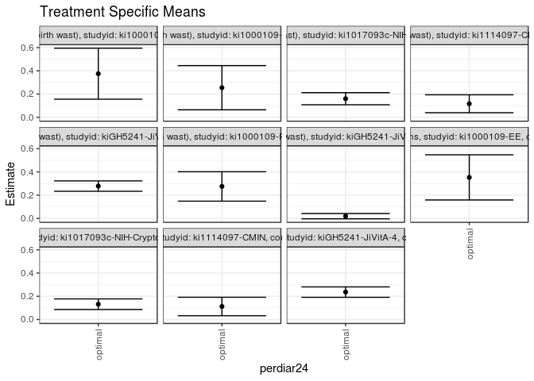

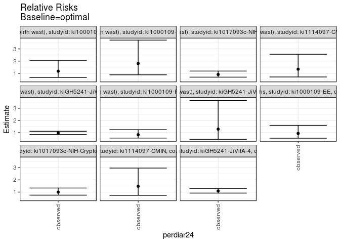

## Results Table

### Parameter: TSM

| agecat | studyid | country | intervention_level | baseline_level | estimate | ci_lower | ci_upper |
| --- | --- | --- | --- | --- | --- | --- | --- |
| 0-24 months (no birth wast) | ki1000109-EE | PAKISTAN | optimal | NA | 0.3751288 | 0.1553987 | 0.5948590 |
| 0-24 months (no birth wast) | ki1000109-ResPak | PAKISTAN | optimal | NA | 0.2544144 | 0.0641669 | 0.4446618 |
| 0-24 months (no birth wast) | ki1017093c-NIH-Crypto | BANGLADESH | optimal | NA | 0.1597596 | 0.1076748 | 0.2118444 |
| 0-24 months (no birth wast) | ki1114097-CMIN | GUINEA-BISSAU | optimal | NA | 0.1162262 | 0.0391143 | 0.1933382 |
| 0-24 months (no birth wast) | kiGH5241-JiVitA-4 | BANGLADESH | optimal | NA | 0.2779729 | 0.2333482 | 0.3225975 |
| 0-6 months (no birth wast) | ki1000109-ResPak | PAKISTAN | optimal | NA | 0.2748730 | 0.1482306 | 0.4015153 |
| 0-6 months (no birth wast) | kiGH5241-JiVitA-4 | BANGLADESH | optimal | NA | 0.0188288 | -0.0040317 | 0.0416892 |
| 6-24 months | ki1000109-EE | PAKISTAN | optimal | NA | 0.3529309 | 0.1584368 | 0.5474251 |
| 6-24 months | ki1017093c-NIH-Crypto | BANGLADESH | optimal | NA | 0.1315769 | 0.0858345 | 0.1773193 |
| 6-24 months | ki1114097-CMIN | GUINEA-BISSAU | optimal | NA | 0.1118231 | 0.0324247 | 0.1912215 |
| 6-24 months | kiGH5241-JiVitA-4 | BANGLADESH | optimal | NA | 0.2357723 | 0.1907805 | 0.2807641 |

### Parameter: E(Y)

| agecat | studyid | country | intervention_level | baseline_level | estimate | ci_lower | ci_upper |
| --- | --- | --- | --- | --- | --- | --- | --- |
| 0-24 months (no birth wast) | ki1000109-EE | PAKISTAN | observed | NA | 0.4376658 | 0.3875213 | 0.4878102 |
| 0-24 months (no birth wast) | ki1000109-ResPak | PAKISTAN | observed | NA | 0.4578755 | 0.3986666 | 0.5170843 |
| 0-24 months (no birth wast) | ki1017093c-NIH-Crypto | BANGLADESH | observed | NA | 0.1432361 | 0.1182149 | 0.1682572 |
| 0-24 months (no birth wast) | ki1114097-CMIN | GUINEA-BISSAU | observed | NA | 0.1549966 | 0.1364963 | 0.1734969 |
| 0-24 months (no birth wast) | kiGH5241-JiVitA-4 | BANGLADESH | observed | NA | 0.2695285 | 0.2427999 | 0.2962571 |
| 0-6 months (no birth wast) | ki1000109-ResPak | PAKISTAN | observed | NA | 0.2287823 | 0.1786790 | 0.2788855 |
| 0-6 months (no birth wast) | kiGH5241-JiVitA-4 | BANGLADESH | observed | NA | 0.0242947 | 0.0148797 | 0.0337096 |
| 6-24 months | ki1000109-EE | PAKISTAN | observed | NA | 0.3306667 | 0.2829875 | 0.3783458 |
| 6-24 months | ki1017093c-NIH-Crypto | BANGLADESH | observed | NA | 0.1315068 | 0.1069744 | 0.1560393 |
| 6-24 months | ki1114097-CMIN | GUINEA-BISSAU | observed | NA | 0.1651755 | 0.1460754 | 0.1842756 |
| 6-24 months | kiGH5241-JiVitA-4 | BANGLADESH | observed | NA | 0.2576816 | 0.2314541 | 0.2839091 |

### Parameter: RR

| agecat | studyid | country | intervention_level | baseline_level | estimate | ci_lower | ci_upper |
| --- | --- | --- | --- | --- | --- | --- | --- |
| 0-24 months (no birth wast) | ki1000109-EE | PAKISTAN | observed | optimal | 1.1667079 | 0.6595287 | 2.063909 |
| 0-24 months (no birth wast) | ki1000109-ResPak | PAKISTAN | observed | optimal | 1.7997233 | 0.8711316 | 3.718157 |
| 0-24 months (no birth wast) | ki1017093c-NIH-Crypto | BANGLADESH | observed | optimal | 0.8965727 | 0.6812719 | 1.179914 |
| 0-24 months (no birth wast) | ki1114097-CMIN | GUINEA-BISSAU | observed | optimal | 1.3335766 | 0.6953106 | 2.557744 |
| 0-24 months (no birth wast) | kiGH5241-JiVitA-4 | BANGLADESH | observed | optimal | 0.9696216 | 0.8428008 | 1.115526 |
| 0-6 months (no birth wast) | ki1000109-ResPak | PAKISTAN | observed | optimal | 0.8323201 | 0.5577466 | 1.242063 |
| 0-6 months (no birth wast) | kiGH5241-JiVitA-4 | BANGLADESH | observed | optimal | 1.2902954 | 0.4561635 | 3.649705 |
| 6-24 months | ki1000109-EE | PAKISTAN | observed | optimal | 0.9369161 | 0.5484954 | 1.600400 |
| 6-24 months | ki1017093c-NIH-Crypto | BANGLADESH | observed | optimal | 0.9994678 | 0.7498794 | 1.332129 |
| 6-24 months | ki1114097-CMIN | GUINEA-BISSAU | observed | optimal | 1.4771149 | 0.7342563 | 2.971535 |
| 6-24 months | kiGH5241-JiVitA-4 | BANGLADESH | observed | optimal | 1.0929254 | 0.9168934 | 1.302753 |

### Parameter: PAR

| agecat | studyid | country | intervention_level | baseline_level | estimate | ci_lower | ci_upper |
| --- | --- | --- | --- | --- | --- | --- | --- |
| 0-24 months (no birth wast) | ki1000109-EE | PAKISTAN | optimal | NA | 0.0625369 | -0.1513104 | 0.2763843 |
| 0-24 months (no birth wast) | ki1000109-ResPak | PAKISTAN | optimal | NA | 0.2034611 | 0.0192243 | 0.3876979 |
| 0-24 months (no birth wast) | ki1017093c-NIH-Crypto | BANGLADESH | optimal | NA | -0.0165235 | -0.0605020 | 0.0274550 |
| 0-24 months (no birth wast) | ki1114097-CMIN | GUINEA-BISSAU | optimal | NA | 0.0387704 | -0.0370112 | 0.1145519 |
| 0-24 months (no birth wast) | kiGH5241-JiVitA-4 | BANGLADESH | optimal | NA | -0.0084444 | -0.0473064 | 0.0304176 |
| 0-6 months (no birth wast) | ki1000109-ResPak | PAKISTAN | optimal | NA | -0.0460907 | -0.1568203 | 0.0646389 |
| 0-6 months (no birth wast) | kiGH5241-JiVitA-4 | BANGLADESH | optimal | NA | 0.0054659 | -0.0135810 | 0.0245129 |
| 6-24 months | ki1000109-EE | PAKISTAN | optimal | NA | -0.0222642 | -0.2111777 | 0.1666492 |
| 6-24 months | ki1017093c-NIH-Crypto | BANGLADESH | optimal | NA | -0.0000700 | -0.0378739 | 0.0377338 |
| 6-24 months | ki1114097-CMIN | GUINEA-BISSAU | optimal | NA | 0.0533524 | -0.0249700 | 0.1316749 |
| 6-24 months | kiGH5241-JiVitA-4 | BANGLADESH | optimal | NA | 0.0219092 | -0.0198547 | 0.0636732 |

### Parameter: PAF

| agecat | studyid | country | intervention_level | baseline_level | estimate | ci_lower | ci_upper |
| --- | --- | --- | --- | --- | --- | --- | --- |
| 0-24 months (no birth wast) | ki1000109-EE | PAKISTAN | optimal | NA | 0.1428874 | -0.5162343 | 0.5154826 |
| 0-24 months (no birth wast) | ki1000109-ResPak | PAKISTAN | optimal | NA | 0.4443590 | -0.1479322 | 0.7310495 |
| 0-24 months (no birth wast) | ki1017093c-NIH-Crypto | BANGLADESH | optimal | NA | -0.1153586 | -0.4678428 | 0.1524809 |
| 0-24 months (no birth wast) | ki1114097-CMIN | GUINEA-BISSAU | optimal | NA | 0.2501368 | -0.4382061 | 0.6090304 |
| 0-24 months (no birth wast) | kiGH5241-JiVitA-4 | BANGLADESH | optimal | NA | -0.0313301 | -0.1865200 | 0.1035618 |
| 0-6 months (no birth wast) | ki1000109-ResPak | PAKISTAN | optimal | NA | -0.2014609 | -0.7929288 | 0.1948881 |
| 0-6 months (no birth wast) | kiGH5241-JiVitA-4 | BANGLADESH | optimal | NA | 0.2249837 | -1.1921963 | 0.7260052 |
| 6-24 months | ki1000109-EE | PAKISTAN | optimal | NA | -0.0673314 | -0.8231695 | 0.3751561 |
| 6-24 months | ki1017093c-NIH-Crypto | BANGLADESH | optimal | NA | -0.0005325 | -0.3335477 | 0.2493217 |
| 6-24 months | ki1114097-CMIN | GUINEA-BISSAU | optimal | NA | 0.3230046 | -0.3619223 | 0.6634736 |
| 6-24 months | kiGH5241-JiVitA-4 | BANGLADESH | optimal | NA | 0.0850245 | -0.0906393 | 0.2323950 |